# R Notebook

```r
#install.packages("gganimate")
#install.packages("gifski")
#install.packages("png")
#install.packages("ggrepel")
#install.packages("ggpubr")
packages <- c("tidyverse", "reshape2", "fauxnaif", "gganimate", "ggthemes",
              "stringr", "gridExtra", "gifski", "png", "ggrepel", "ggpubr")
lapply(packages, require, character.only = TRUE)
```

```
[[1]]
[1] TRUE

[[2]]
[1] TRUE

[[3]]
[1] TRUE

[[4]]
[1] TRUE

[[5]]
[1] TRUE

[[6]]
[1] TRUE

[[7]]
[1] TRUE

[[8]]
[1] TRUE

[[9]]
[1] TRUE

[[10]]
[1] TRUE

[[11]]
[1] TRUE
```

```r
# Load data
africa_energy <- read.csv("../data/african-regional-energy-statistics-2014.csv")
world_gdp <- read.csv("../data/WorldGDP.csv")
```

```r
# Combine datasets
world_gdp %>%
  select(Country.Name, starts_with("X")) %>%
  melt(id.vars = c("Country.Name")) -> world_gdp_sub_T
world_gdp_sub_T$variable <- as.numeric(gsub("^.{0,1}", "", world_gdp_sub_T$variable))
world_gdp_sub_T <- rename(world_gdp_sub_T, RegionName=Country.Name, Date=variable, GDP=value)
africa_energy %>%
  select(-IndicatorName) %>%
  left_join(y=world_gdp_sub_T) %>%
  dcast(...~Indicator, value.var="Value") -> africa_join
africa_energy <- as.numeric(africa_energy$Date)
```

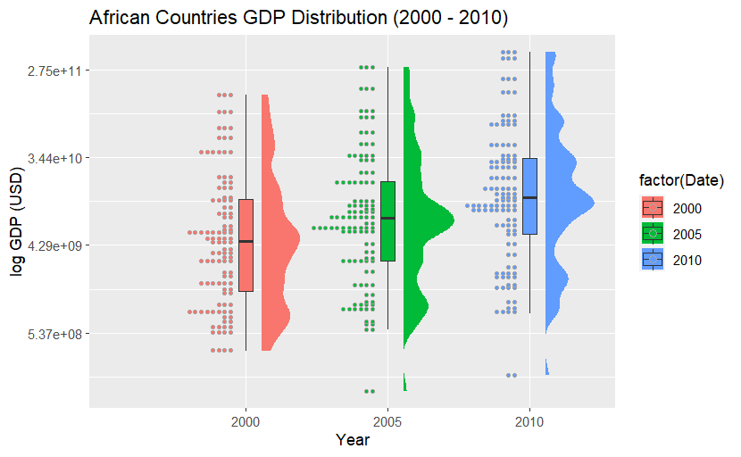

```r
africa_join %>%
  filter(Region > 10000) %>%
  select(RegionName, GDP, Date) %>%
  filter(Date==2000 | Date==2005 | Date==2010) %>%
  mutate(Date=as.character(Date)) %>%
  ggplot(aes(x=Date, y=GDP, fill=factor(Date))) +
  xlab("Year") + ylab("log GDP (USD)") + ggtitle("African Countries GDP Distribution (2000 - 2010)") +
  ggdist::stat_halfeye(adjust = .5, width = .4, .width = 0, justification = -.3, point_colour = NA) + # Draw the density plot
  scale_y_continuous(trans='log2', labels = function(x) formatC(x, format = "e", digits = 2)) + # Make this a log plot (log-normal)
  geom_boxplot(width = 0.1, outlier.shape = NA) + # Draw box plot to show uncertainty
  ggdist::stat_dots(side = "left", dotsize = 2, justification = 1.1, binwidth = .1) # Draw the dot plot

ggsave("../static/Africa-GDP-Dist.png", dpi=1200, bg="white")
```

Uncertainty is displayed and calculated automatically using the geom_boxplot function, showing the different quartiles of the country’s GDP in Africa from 2000 to 2010. Uncertainty is depicted using median and IQR since there are outliers in the dataset. I chose a log scale for GDP to make the plot easier to visualize. The added benefit is that people can easily see that the distribution of country GDPs in Africa roughly follows a log-normal distribution, indicating right-skew. The added dot plot and density plot is used to further depict nuances in the distribution for each year.

```r
tuition <- read.csv("../data/college-tuition-2018.csv")
```

```r
# Select relevant data
public_in_state <- tuition %>%
  filter(type=="Public") %>%
  select(type, in.state.cost)

public_out_state <- tuition %>%
  filter(type=="Public") %>%
  select(type, out.state.cost)

private_no_profit <- tuition %>%
  filter(type=="Private") %>%
  select(type, in.state.cost)

private_for_profit <- tuition %>%
  filter(type=="For-Profit") %>%
  select(type, in.state.cost)
```

```r
# Calculate median, Q1, and Q3 for different university types because of outliers
public_in_state %>%
  summarise(median_tuition = median(in.state.cost),  Q1_tuition=quantile(in.state.cost, probs=0.25), Q3_tuition=quantile(in.state.cost, probs=0.75)) -> public_in_state_stat

public_out_state %>%
  summarise(median_tuition = median(out.state.cost), Q1_tuition=quantile(out.state.cost, probs=0.25), Q3_tuition=quantile(out.state.cost, probs=0.75)) -> public_out_state_stat

private_no_profit %>%
  summarise(median_tuition = median(in.state.cost), Q1_tuition=quantile(in.state.cost, probs=0.25), Q3_tuition=quantile(in.state.cost, probs=0.75)) -> private_no_profit_stat

private_for_profit %>%
  summarise(median_tuition = median(in.state.cost), Q1_tuition=quantile(in.state.cost, probs=0.25), Q3_tuition=quantile(in.state.cost, probs=0.75)) -> private_for_profit_stat
```

```r
tuition_join <- rbind(public_in_state_stat, public_out_state_stat, private_for_profit_stat, private_no_profit_stat)
tuition_join <- cbind(type=c("Public in-State", "Public out-of-State", "Private for-Profit", "Private non-Profit"), tuition_join)
```

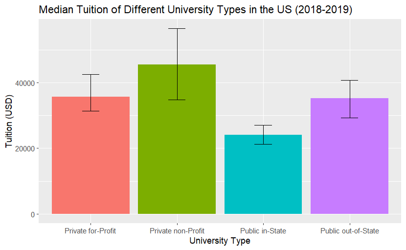

```r
tuition_join %>%
  ggplot(aes(x=type, y=median_tuition, fill=type)) +
  geom_bar(stat = "identity") + # draw the bar chart, currently without uncertainties
  geom_errorbar(aes(ymin=Q1_tuition, ymax=Q3_tuition,  width=.2)) +  # add in the error bars with first and third quartiles
  xlab("University Type") + ylab("Tuition (USD)") + ggtitle("Median Tuition of Different University Types in the US (2018-2019)") +
  theme(legend.position = "none")
ggsave("../static/University-Tuition.png", dpi=1200, bg="white")
```

I calculated uncertainty by taking the median, Q1, and Q3 of different university types across the US since the dataset contains outliers. I chose to represent the median using the height of the bar chart and the IQR using the error bars since this allows the user to easily see the spread of the data and roughly pick out the percentage overlap between tuition rates of different university types.